# Samples and Sampling Distributions

Emorie Beck

2/16/2018

```r
library(knitr)
library(kableExtra)

dat %>% select(Initials, Section, Age, Height) %>%
  kable(., "html", booktabs = T, digits = 2, escape = F) %>%
  kable_styling(bootstrap_options = c("striped"), full_width = T) %>%
  scroll_box(width = "750px", height = "300px")
```

| Initials | Section | Age | Height |
| --- | --- | --- | --- |
| GG | 4 | 19 | 62.0 |
| MC | 4 | 19 | 63.0 |
| aez | 4 | 19 | 69.0 |
| SP | 4 | 21 | 63.0 |
| CW | 4 | 22 | 72.0 |
| TM | 4 | 19 | 64.0 |
| ML | 4 | 20 | 69.0 |
| MF | 4 | 19 | 61.0 |
| MK | 4 | 19 | 68.5 |
| SS | 4 | 20 | 64.0 |
| NC | 4 | 18 | 70.0 |
| EG | 4 | 18 | 67.0 |
| SNG | 4 | 18 | 65.0 |
| HR | 4 | 21 | 68.0 |
| AS | 4 | 18 | 64.0 |
| AL | 4 | 18 | 62.0 |
| AA | 4 | 19 | 63.0 |
| MN | 4 | 19 | NA |
| KW | 4 | 21 | 56.0 |
| NK | 4 | 19 | 66.0 |
| GA | 4 | 19 | 67.0 |
| DN | 4 | 20 | 67.0 |
| GC | 4 | 20 | 66.0 |
| TS | 4 | 19 | 69.0 |
| JF | 4 | 20 | 72.5 |
| ST | 4 | 19 | 66.0 |
| JC | 4 | 21 | 72.0 |
| RK | 4 | 19 | 71.0 |
| NG | 4 | 20 | 62.0 |
| SC | 4 | 19 | 62.0 |

[output cut: 130 more lines]

And we can also plot a distribution for this *population*.

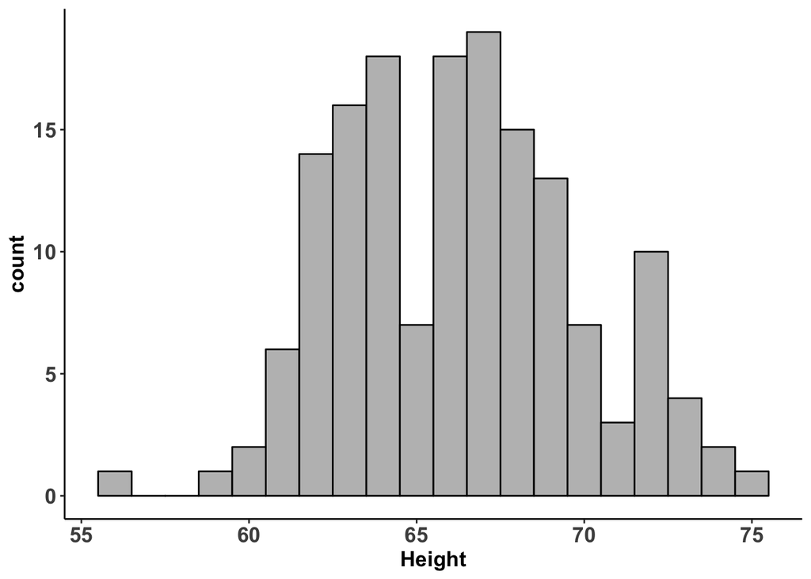

```r
dat %>%
  ggplot(aes(x = Height)) +
    geom_histogram(binwidth = 1, color = "black", fill = "gray") +
    theme_classic() +
    theme(axis.text = element_text(face = "bold", size = rel(1.2)),
          axis.title = element_text(face = "bold", size = rel(1.2)))
```

# Sample Distributions

We can also take samples from our population (the class) of height.

## Raw values

```r
sample1 <- dat %>% select(Initials, Section, Age, Height) %>%
  filter(row_number() %in% sample(1:nrow(dat),15))

sample1 %>%
  kable(., "html", booktabs = T, digits = 2, escape = F) %>%
  kable_styling(bootstrap_options = c("striped"), full_width = T) %>%
  scroll_box(width = "750px", height = "150px")
```

| Initials | Section | Age | Height |
| --- | --- | --- | --- |
| MC | 4 | 19 | 63 |
| SP | 4 | 21 | 63 |
| ML | 4 | 20 | 69 |
| NC | 4 | 18 | 70 |
| KW | 4 | 21 | 56 |
| NG | 4 | 20 | 62 |
| TP | 4 | 17 | 68 |
| SC | 4 | 19 | 66 |
| SR | 4 | 19 | 63 |
| ZZ | 4 | 19 | 66 |
| OB | 4 | 19 | 67 |
| AN | 3 | 20 | 64 |
| EB | 3 | 18 | 66 |
| HB | 3 | 22 | 67 |
| CP | 3 | 19 | 65 |

```r
sample2 <- dat %>% select(Initials, Section, Age, Height) %>%
  filter(row_number() %in% sample(1:nrow(dat),15))

sample2 %>%
  kable(., "html", booktabs = T, digits = 2, escape = F) %>%
  kable_styling(bootstrap_options = c("striped"), full_width = T) %>%
  scroll_box(width = "750px", height = "150px")
```

| Initials | Section | Age | Height |
| --- | --- | --- | --- |
| NC | 4 | 18 | 70 |
| AS | 4 | 18 | 64 |
| NK | 4 | 19 | 66 |
| RK | 4 | 19 | 71 |
| AG | 4 | 19 | 62 |
| EL | 4 | 19 | 67 |
| IS | 4 | 21 | 68 |
| DM | 4 | 20 | 72 |
| JF | 3 | 19 | 68 |
| SB | 3 | 19 | 70 |
| SG | 3 | 18 | 61 |
| TW | 3 | 19 | 64 |
| MF | 3 | 18 | 66 |
| DS | 3 | 18 | 74 |
| GB | 3 | 20 | 62 |

## Distributions

And look at their distributions.

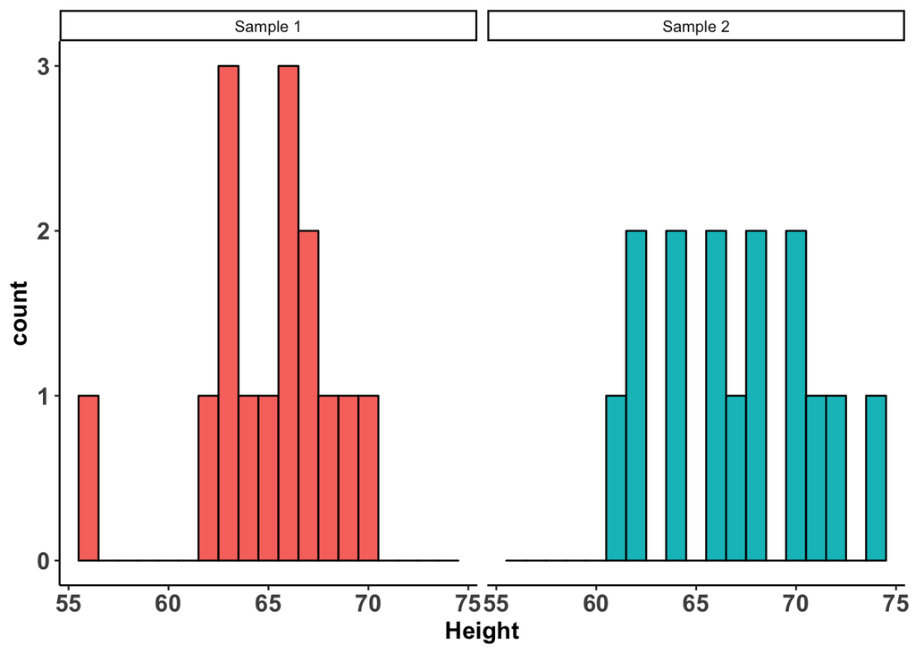

```r
sample1 %>% mutate(sample = "Sample 1") %>%
  full_join(sample2 %>% mutate(sample = "Sample 2")) %>%
  ggplot(aes(x = Height, fill = sample)) +
    geom_histogram(binwidth = 1, color = "black") +
    facet_grid(.~sample) +
    theme_classic() +
    theme(axis.text = element_text(face = "bold", size = rel(1.2)),
          axis.title = element_text(face = "bold", size = rel(1.2)),
          legend.position = "none")
```

## Summary Statistics

And summary statistics:

```r
sample1 %>% mutate(sample = "Sample 1") %>%
  full_join(sample2 %>% mutate(sample = "Sample 2")) %>%
  group_by(sample) %>%
  summarize(Mean = mean(Height, na.rm = T),
            SD = sd(Height, na.rm = T),
            Min = min(Height, na.rm = T),
            Max = max(Height, na.rm = T))  %>%
  kable(., "html", booktabs = T, digits = 2, escape = F) %>%
  kable_styling(bootstrap_options = c("striped"), full_width = T)
```

| sample | Mean | SD | Min | Max |
| --- | --- | --- | --- | --- |
| Sample 1 | 65 | 3.42 | 56 | 70 |
| Sample 2 | 67 | 3.93 | 61 | 74 |

# 100 Samples

They’re pretty close. What if we did this 100 times?

## Raw values

```r
sample_fun <- function(df, size){
  dat %>% select(Initials, Section, Age, Height) %>%
    filter(row_number() %in% sample(1:nrow(dat),size))
}

sampled <- tibble(Sample = 1:100) %>%
  mutate(data = map(Sample, ~sample_fun(., 15)))
sampled %>%
  unnest(data) %>%
  group_by(Sample) %>%
  summarize(Mean = mean(Height, na.rm = T),
            SD = sd(Height, na.rm = T),
            Min = min(Height, na.rm = T),
            Max = max(Height, na.rm = T))  %>%
  kable(., "html", booktabs = T, digits = 2, escape = F) %>%
  kable_styling(bootstrap_options = c("striped"), full_width = T) %>%
  scroll_box(width = "750px", height = "300px")
```

| Sample | Mean | SD | Min | Max |
| --- | --- | --- | --- | --- |
| 1 | 68.43 | 3.87 | 62 | 75.0 |
| 2 | 66.27 | 4.20 | 61 | 74.0 |
| 3 | 67.03 | 3.44 | 59 | 72.5 |
| 4 | 66.87 | 3.58 | 62 | 75.0 |
| 5 | 65.90 | 2.98 | 60 | 69.0 |
| 6 | 65.60 | 2.72 | 62 | 70.0 |
| 7 | 66.43 | 3.99 | 61 | 72.5 |
| 8 | 66.00 | 3.61 | 61 | 73.0 |
| 9 | 66.27 | 2.94 | 62 | 73.0 |
| 10 | 65.71 | 3.10 | 61 | 72.0 |
| 11 | 66.13 | 3.58 | 62 | 72.0 |
| 12 | 66.71 | 3.07 | 62 | 71.0 |
| 13 | 66.29 | 2.81 | 62 | 73.0 |
| 14 | 66.60 | 3.74 | 61 | 72.0 |
| 15 | 65.21 | 4.30 | 56 | 73.0 |
| 16 | 64.67 | 3.44 | 60 | 69.0 |
| 17 | 67.07 | 3.51 | 61 | 73.0 |
| 18 | 65.97 | 2.87 | 61 | 72.0 |
| 19 | 65.87 | 3.60 | 61 | 72.0 |
| 20 | 66.07 | 4.40 | 60 | 75.0 |
| 21 | 65.83 | 3.01 | 60 | 70.0 |
| 22 | 66.63 | 3.41 | 59 | 73.0 |
| 23 | 66.64 | 3.34 | 61 | 73.0 |
| 24 | 67.64 | 4.34 | 62 | 75.0 |
| 25 | 67.43 | 3.57 | 62 | 75.0 |
| 26 | 65.20 | 3.41 | 61 | 73.0 |
| 27 | 66.83 | 3.70 | 62 | 72.0 |
| 28 | 66.73 | 3.37 | 62 | 72.0 |
| 29 | 67.00 | 4.34 | 62 | 75.0 |
| 30 | 66.33 | 3.04 | 61 | 72.0 |

[output cut: 70 more lines]

## Distribution

The means vary some. What if we look at the distribution in a histogram?

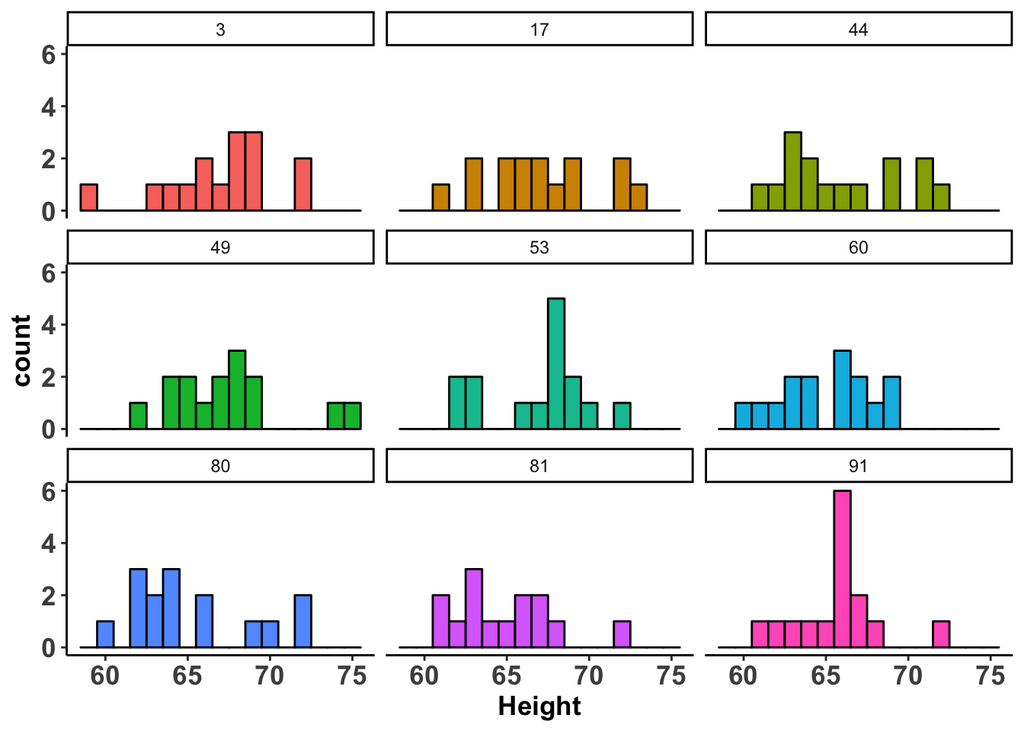

```r
sampled %>%
  unnest(data) %>%
  filter(Sample %in% sample(1:100, 9)) %>%
  ggplot(aes(x = Height, fill = factor(Sample))) +
    geom_histogram(binwidth = 1, color = "black") +
    facet_wrap(~Sample, nrow = 3) +
    theme_classic() +
    theme(axis.text = element_text(face = "bold", size = rel(1.2)),
          axis.title = element_text(face = "bold", size = rel(1.2)),
          legend.position = "none")
```

## Sampling Distribution

And now what if we look at a distribution of the sample means?

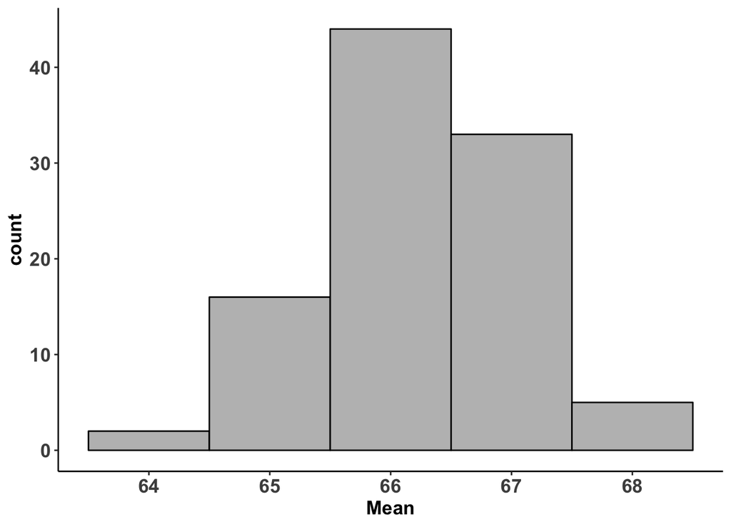

```r
sampled %>%
  unnest(data) %>%
  group_by(Sample) %>%
  summarize(Mean = mean(Height, na.rm = T)) %>%
  ggplot(aes(x = Mean)) +
    geom_histogram(binwidth = 1, color = "black", fill = "gray") +
    theme_classic() +
    theme(axis.text = element_text(face = "bold", size = rel(1.2)),
          axis.title = element_text(face = "bold", size = rel(1.2)))
```

That looks more normal than the distribution of values in each sample.

# Varying Sample Size

Let’s play with the number of samples.

```r
sampling_fun <- function(size, sample_size){
  tibble(Sample = 1:size) %>%
    mutate(data = map(Sample, ~sample_fun(., sample_size))) %>%
    unnest(Sample)
}

sampled2 <- expand.grid(
  Num_Samples = c(10, 100, 1000, 10000),
  Sample_Size = 15) %>%
  tbl_df %>%
  mutate(samples = map2(Num_Samples, Sample_Size, sampling_fun))
```

## Distributions

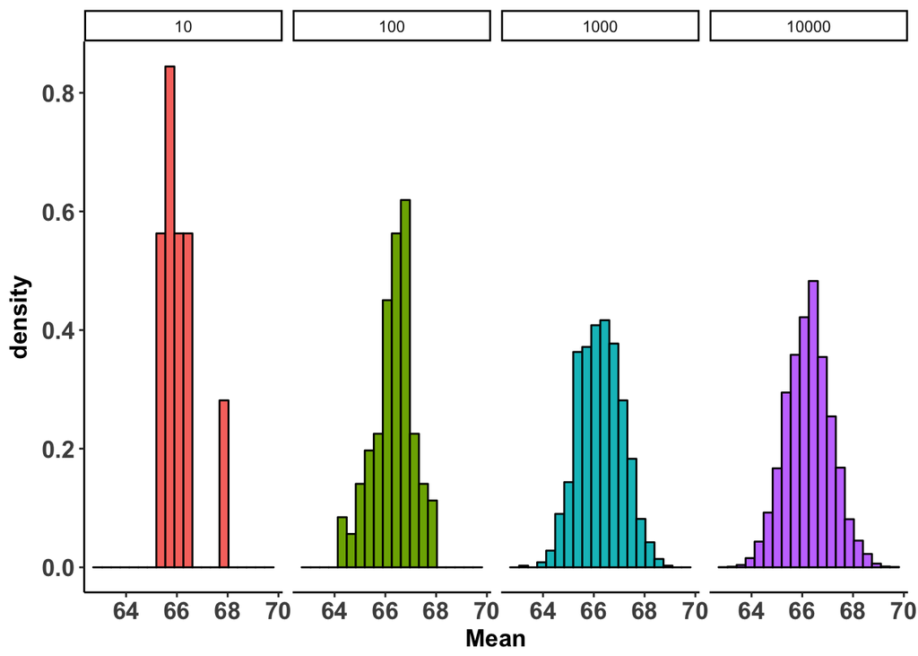

```r
sampled2 %>% unnest(samples) %>% unnest(data) %>%
  group_by(Num_Samples, Sample) %>%
  summarize(Mean = mean(Height, na.rm = T)) %>%
  ggplot(aes(x = Mean, y = ..density.., fill = factor(Num_Samples))) +
    geom_histogram(color = "black", bins = 20) +
    facet_grid(.~Num_Samples) +
    theme_classic() +
    theme(axis.text = element_text(face = "bold", size = rel(1.2)),
          axis.title = element_text(face = "bold", size = rel(1.2)),
          legend.position = "none")
```

Notably, our originally non-normal data now looks normal!!

## Standard Error of the Mean

And we can get something important from this: standard errors, which are the standard deviation of the sampling distribution of the mean.

```r
sampled2 %>% unnest(samples) %>% unnest(data) %>%
  group_by(Num_Samples, Sample) %>%
  summarize(Mean = mean(Height, na.rm = T)) %>%
  group_by(Num_Samples) %>%
  summarize(SD = sd(Mean, na.rm = T))
```

| Num_Samples | SD |
| --- | --- |
| 10 | 0.7868392 |
| 100 | 0.8001407 |
| 1000 | 0.8603820 |
| 10000 | 0.8915997 |

Don’t worry about the fact that the standard errors get larger. Note instead that once we hit 1000 and 10000, they are consistent – they are better estimates.

# Central Limit Theorum

But wait, aren’t standard errors supposed to get smaller? Yes but with larger SAMPLE SIZES, not more samples. Watch:

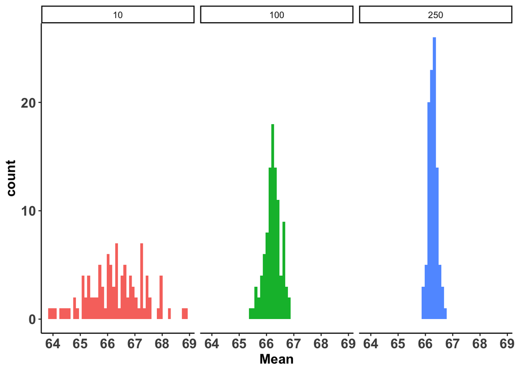

```r
sample_fun <- function(df, size){
  dat %>% select(Initials, Section, Age, Height) %>%
    filter(row_number() %in% sample(nrow(dat), size, replace = T))
}

sampled3 <- expand.grid(
  Num_Samples = c(10, 100, 1000, 10000),
  Sample_Size = c(10,100,250),
  stringsAsFactors = F) %>%
  tbl_df %>%
  mutate(data = map2(Num_Samples, Sample_Size, sampling_fun))

sampled3 %>%
  unnest(data) %>% unnest(data) %>%
  filter(Num_Samples == 100) %>%
  group_by(Sample, Sample_Size) %>%
  summarize(Mean = mean(Height, na.rm = T)) %>%
  ggplot(aes(x = Mean,  fill = factor(Sample_Size))) +
    geom_histogram(bins = 50) +
    facet_grid(.~Sample_Size) +
    theme_classic() +
    theme(axis.text = element_text(face = "bold", size = rel(1.2)),
          axis.title = element_text(face = "bold", size = rel(1.2)),
          legend.position = "none")
```

And this is the central limit theorum. Our estimates more closely approximate reality and even non-normal distributions of real data approximate normal when looking at means. Plus, when we look at the SD’s, they’ve gotten A LOT narrower.

```r
sampled3 %>% unnest(data) %>% unnest(data) %>%
  filter(Num_Samples == 100) %>%
  group_by(Sample_Size, Sample) %>%
  summarize(Mean = mean(Height, na.rm = T)) %>%
  group_by(Sample_Size) %>%
  summarize(SD = sd(Mean, na.rm = T))
```

| Sample_Size | SD |
| --- | --- |
| 10 | 1.0398888 |
| 100 | 0.2977866 |
| 250 | 0.1587483 |